# Reliability Analysis

ChatGPT 4o

2025-01-21

## 1 起源

信度分析（Reliability Analysis）起源于心理测量学，最早由Charles Spearman和其他心理学家在20世纪初提出，用于评估测量工具（如问卷、测试）的一致性和稳定性。信度分析是心理学、教育学、社会科学等领域的重要组成部分，旨在确保测量工具所收集的数据具有可重复性和可靠性。

## 2 原理

信度分析的核心是衡量测量工具的一致性和稳定性，即测量结果是否在不同时间、不同情境或不同测量者之间保持一致。常见的信度指标包括：

- **Cronbach’s Alpha**：用于衡量量表各题目之间的内在一致性，取值范围为0到1，值越大表示一致性越好。
  $$\alpha = \frac{k}{k-1} \left( 1 - \frac{\sum s_i^2}{s_t^2} \right)$$
  其中，$k$ 为题目数量，$s_i^2$ 为第$i$个题目的方差，$s_t^2$ 为总得分的方差。
- **分半信度（Split-Half Reliability）**：将量表题目随机分为两半，计算两半得分的相关性，通常使用Spearman-Brown公式进行修正。
  $$r_{SB} = \frac{2r_{xy}}{1 + r_{xy}}$$
  其中，$r_{xy}$ 为两半得分之间的相关系数。
- **重测信度（Test-Retest Reliability）**：在不同时间对同一组受试者进行多次测量，计算不同时间点得分的相关性。
- **组合信度（Composite Reliability, CR）**：用于验证性因素分析中，衡量潜变量的内部一致性。
  $$CR = \frac{(\sum \lambda_i)^2}{(\sum \lambda_i)^2 + \sum \theta_i}$$
  其中，$\lambda_i$ 为因子负荷，$\theta_i$ 为测量误差。

## 3 适用范围

信度分析适用于以下情况：

- **心理测量和教育测评**：评估问卷、测试工具的可靠性，确保测量结果的稳定性和一致性。
- **社会科学调查**：用于评估调查问卷的质量，确保数据的可靠性。
- **市场研究**：用于评估客户满意度问卷、市场调查工具的信度，以保证调查结果的可靠性。

## 4 应用情境

信度分析在多个领域中有广泛的应用，例如：

- **教育学**：评估学生测试题的内在一致性，确保测试分数的可靠性。
- **心理学**：用于评估心理测量工具（如焦虑量表、人格问卷）的信度，确保测量结果稳定可靠。
- **社会科学研究**：用于评估社会调查问卷的内部一致性和测量稳定性，确保研究数据的质量。
- **医学领域**：用于评估健康问卷、生活质量调查工具的信度，确保临床研究数据的可靠性。

## 5 优缺点

### 优点

- **评估工具的一致性**：信度分析可以量化测量工具的内在一致性，确保测量结果的稳定性。
- **提高研究的信任度**：通过评估信度，研究人员可以判断测量工具是否适合用于数据收集，从而提高研究结果的信任度。
- **适用于多种测量工具**：信度分析可以用于评估不同类型的测量工具，如问卷、测试、调查量表等。

### 缺点

- **仅衡量一致性**：信度分析只能衡量测量工具的一致性，无法判断测量工具是否有效（即是否真正测量了所需的内容）。
- **受样本影响较大**：信度系数的大小可能会受到样本特征的影响，不同样本可能会得到不同的信度系数。
- **对问卷长度敏感**：Cronbach’s Alpha对问卷的长度比较敏感，题目数量过少可能导致信度系数偏低。

## 6 在R中的实现及结果解释

在R中，可以使用`psych`包或`ltm`包来计算信度指标，以下是一个使用`psych`包计算Cronbach’s Alpha的示例：

```r
# 加载必要的包
library(psych)

# 示例数据：生成假设的量表数据
set.seed(123)
data <- data.frame(
  item1 = sample(1:5, 100, replace = TRUE),
  item2 = sample(1:5, 100, replace = TRUE),
  item3 = sample(1:5, 100, replace = TRUE),
  item4 = sample(1:5, 100, replace = TRUE),
  item5 = sample(1:5, 100, replace = TRUE)
)

# 计算Cronbach's Alpha，考虑负相关题目需要反向编码
alpha_result <- alpha(data, check.keys = TRUE)
# 输出Cronbach's Alpha结果
summary(alpha_result)
```

```
##
## Reliability analysis
##  raw_alpha std.alpha G6(smc) average_r  S/N  ase mean  sd median_r
##        0.2      0.21     0.2     0.051 0.27 0.13    3 0.7   0.0095
```

```r
str(alpha_result)
```

[output not shown]

```r
print(alpha_result$total)
```

```
##  raw_alpha std.alpha   G6(smc)  average_r       S/N       ase  mean        sd
##  0.2029055 0.2121724 0.1951779 0.05110975 0.2693133 0.1262145 3.004 0.7009258
##     median_r
##  0.009518978
```

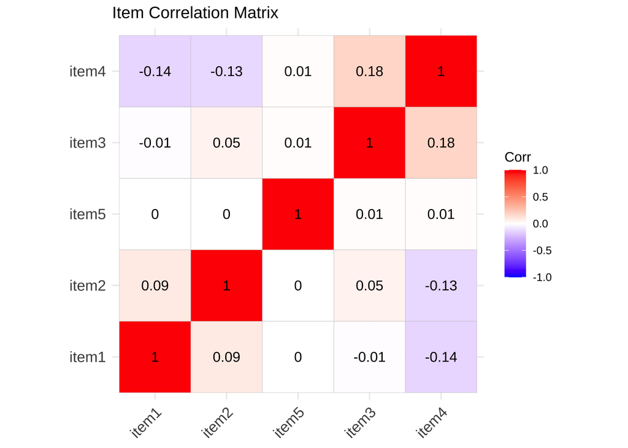

```r
# 可视化：绘制各题目之间的相关性矩阵
cor_matrix <- cor(data)
library(ggcorrplot)
ggcorrplot(cor_matrix, lab = TRUE, title = "Item Correlation Matrix", hc.order = TRUE)
```

### 结果解释

- **Cronbach’s Alpha结果**：通过`alpha()`函数计算Cronbach’s Alpha值，用于衡量量表各题目之间的内在一致性。使用`check.keys = TRUE`参数，自动处理了负相关题目反向编码的问题。通常，Alpha值大于0.7表示量表具有良好的信度。
- **相关性矩阵可视化**：通过相关性矩阵的可视化，可以直观地查看各题目之间的相关程度。相关性越高，通常表示题目之间的一致性越好。

### 结果的可视化

通过绘制各题目之间的相关性矩阵，可以直观了解题目之间的一致性程度，帮助判断量表的内在一致性。

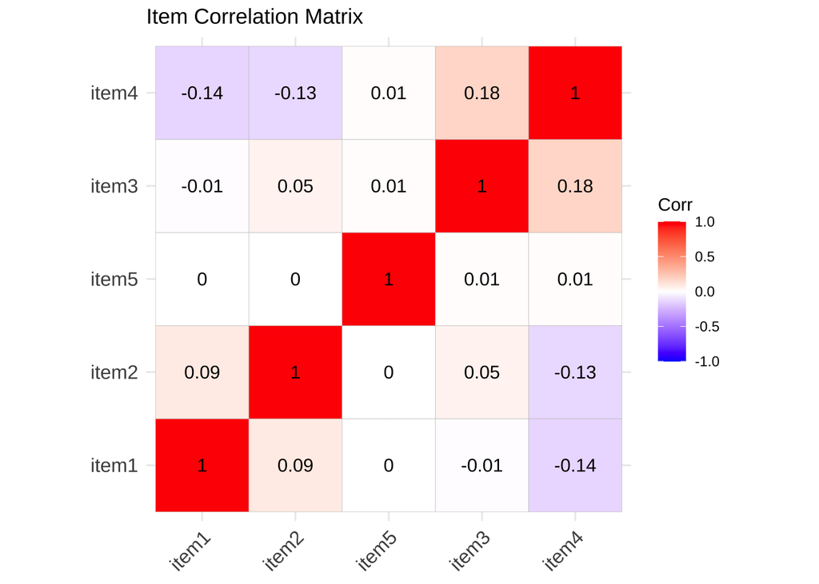

```r
# 使用ggcorrplot绘制各题目之间的相关性矩阵
library(ggcorrplot)
ggcorrplot(cor_matrix, lab = TRUE, title = "Item Correlation Matrix", hc.order = TRUE)
```

## 7 小结

- 信度分析是一种用于评估测量工具一致性和稳定性的统计方法，广泛应用于心理学、教育学和社会科学等领域。
- 常见的信度指标包括Cronbach’s Alpha、分半信度、重测信度等，适用于不同类型的测量工具。
- 具有量化测量工具一致性、提高研究信任度等优点，但只能衡量一致性，不能评估测量工具的有效性。
- 可以通过R中的`psych`包计算信度指标，并结合可视化工具直观展示各题目之间的相关性。